# STEP3_HlineCalculating_2

#### **STEP3** 基于DMRG计算线性氢链H_n的基态能量和键级

代码撰写：李思绎 王江腾

```python
import numpy as np
from pyscf import gto, scf, lo
from pyblock2._pyscf.ao2mo import integrals as itg
from pyblock2.driver.core import DMRGDriver, SymmetryTypes
```

#### **1. block2的基本用法**

DMRG计算的基本流程

- 定义系统（PySCF/mol）
- 初始化Driver（对称性/轨道/电子）
- 构建MPO（哈密顿量）
- DMRG扫荡（优化MPS）

##### **1.1** 初始化DMRG driver

```
from pyblock2.driver.core import DMRGDriver, SymmetryTypes

driver = DMRGDriver(
    scratch="./tmp",              # 临时文件目录（存放 MPS 中间数据）
    symm_type=SymmetryTypes.SU2,  # 对称性类型
    n_threads=4                   # 并行线程数
)
```

##### **1.2** 初始化系统信息

```
driver.initialize_system(
    n_sites=ncas,     # 轨道数（MPS 的格点数）
    n_elec=n_elec,    # 电子数
    spin=spin,        # 自旋（2S，单重态=0，三重态=2）
)
```

##### **1.3** 构建MPO

```
mpo = driver.get_qc_mpo(
    h1e=h1e,     # 单电子积分（动能+核吸引）
    g2e=g2e,     # 双电子积分（电子排斥，化学符号 (ij|kl)）
    ecore=ecore, # 核排斥能常数
    iprint=1     # 打印 MPO 信息
)
```

##### **1.4** 设置初始MPS

```
ket = driver.get_random_mps(
    tag="GS",       # MPS 标签
    bond_dim=250,   # 初始键维度
    nroots=1        # 求解态的数量（1=只求基态）
)
```

##### **1.5** DMRG扫荡

```
energy = driver.dmrg(
    mpo,          # 哈密顿量 MPO
    ket,          # 初始 MPS
    n_sweeps=20,  # 最大扫荡次数
    bond_dims=[250]*4 + [500]*4,  # 每次扫荡的 bond_dim
    noises=[1e-4]*4 + [1e-5]*4 + [0],  # 每次扫荡的噪声
    thrds=[1e-10]*8,  # 每次扫荡的 Lanczos 收敛阈值
    iprint=1       # 打印级别
)
```

*扫荡参数的选择*

- 扫荡 0-3： bond_dim=250, noise=1e-4 ← 低精度快速逼近
- 扫荡 4-7： bond_dim=500, noise=1e-5 ← 提高精度，噪声衰减
- 扫荡 8+ ： bond_dim=500, noise=0 ← 最终精确收敛

##### **1.6** 后续计算/结果输出

#### **2. 单个氢分子基态（$H_2$）**

##### **2.1** 分子结构与分子轨道建构

（PySCF）建立分子结构：

- `atom="H 0 0 0; H 0 0 0.74"` 2和H原子位于同一条直线，一个位于原点，另一个相距0.74A处（符合化学中H2分子平均键长的观测结果）
- `basis="ato3g"` 使用STO-3G最小基组（每个原子3个高斯函数拟合1个轨道）
- `symmetry="d2h""` 对称性

RHF（Restricted Hartree-Fock）平均近似场计算初始分子轨道：

- `conv_tol=1e-12` 控制收敛精度
- `mf = scf.RHF(mol).run()` 简化模型，认为电子a的势场只取决于原子核的吸引和电子b的平均分布产生的库仑势。（给DMRG提供一个初始的分子轨道，DMRG会进一步修正）

```python
mol = gto.M(atom="H 0 0 0; H 0 0 0.74", basis="sto3g", symmetry="d2h", verbose=0)
mf = scf.RHF(mol).run(conv_tol=1e-12)
```

##### **2.2** 设置哈密顿量

$H_2$的哈密顿量： $$ H = -\frac{1}{2}\nabla_1^2 - \frac{1}{2}\nabla_2^2 - \frac{1}{|\mathbf{r}_1-\mathbf{R}_a|} - \frac{1}{|\mathbf{r}_1-\mathbf{R}_b|} - \frac{1}{|\mathbf{r}_2-\mathbf{R}_a|} - \frac{1}{|\mathbf{r}_2-\mathbf{R}_b|} + \frac{1}{|\mathbf{r}_1-\mathbf{r}_2|} + \frac{1}{|\mathbf{R}_a-\mathbf{R}_b|} $$
这是个连续空间的微分方程，无法被DMRG直接处理；需要把H投影到RHF计算出来的分子轨道上

- 单电子积分h1e： $$ h_{pq} = \int \psi_p^*(\mathbf{r}) \left[ -\frac{1}{2}\nabla^2 - \frac{1}{|\mathbf{r}-\mathbf{R}_a|} - \frac{1}{|\mathbf{r}-\mathbf{R}_b|} \right] \psi_q(\mathbf{r}) \, d\mathbf{r} $$
- 双电子积分g2e： $$ g_{pqrs} = \iint \psi_p^*(\mathbf{r}_1) \psi_q(\mathbf{r}_1) \, \frac{1}{|\mathbf{r}_1-\mathbf{r}_2|} \, \psi_r^*(\mathbf{r}_2) \psi_s(\mathbf{r}_2) \, d\mathbf{r}_1 d\mathbf{r}_2 $$ 最后利用这些算符把哈密顿量写成离散形式，这个过程就是哈密顿量的**二次量子化**： $$ \hat{H} = \sum_{pq} h_{pq} \, \hat{a}_p^\dagger \hat{a}_q + \frac{1}{2} \sum_{pqrs} g_{pqrs} \, \hat{a}_p^\dagger \hat{a}_r^\dagger \hat{a}_s \hat{a}_q + E_{\text{core}} $$

```python
ncas, n_elec, spin, ecore, h1e, g2e, orb_sym = itg.get_rhf_integrals(mf, ncore=0, ncas=None, g2e_symm=8)
```

```python
#调试参数临时输出：
print(f"1. 轨道数 (ncas): {ncas}")
print(f"2. 电子数 (n_elec): {n_elec}")
print(f"3. 总自旋 (spin): {spin}")
print(f"4. 核排斥能+核心能量 (ecore): {ecore:.10f} Hartree")
```

```
1. 轨道数 (ncas): 2
2. 电子数 (n_elec): 2
3. 总自旋 (spin): 0
4. 核排斥能+核心能量 (ecore): 0.7151043391 Hartree
```

##### **2.3** DMRG求解

（block2）初始化DMRG：

- `symm_type=SymmetryTypes.SU2` 使用SU(2)自旋对称性
- `n_threads=4"` 使用4线程并行计算
- `n_sites=ncas, n_elec=n_elec, spin=spin, orb_sym=orb_sym"` 输入轨道数、电子数、总自旋，轨道对称性（计算加速）

构建矩阵乘积算符（MPO）：

- `mpo=driver.get_qc_mpo()` 根据RHF的计算结果，分别给出单电子积分h1e、双电子积分g2e、核排斥能ecore和轨道对称性

生成随机MPS波函数：

- `ket=driver.get_random_mps()` 用一个随机的矩阵乘积态mps作为扫荡的开始
- `tag="GS"` 标记为基态

```python
driver = DMRGDriver(scratch="./tmp", symm_type=SymmetryTypes.SU2, n_threads=4)
driver.initialize_system(n_sites=ncas, n_elec=n_elec, spin=spin, orb_sym=orb_sym)
mpo = driver.get_qc_mpo(h1e=h1e, g2e=g2e, ecore=ecore, iprint=0)
ket = driver.get_random_mps(tag="GS", bond_dim=20, nroots=1)
```

设定扫描参数；添加噪声防止陷入局部极小值而得不到全局最小值

```python
n_sweeps = 8
bond_dims = [100] * n_sweeps          # H2 体系 bond_dim=2 即数学精确，100 绝对安全
noises    = [1e-4, 1e-5, 1e-6, 1e-7, 0, 0, 0, 0]
thrds     = [1e-10] * n_sweeps
```

DMRG计算

- 此处手动修改`iprint=1`可显示每次扫荡输出

```python
energy_DMRG = driver.dmrg(mpo, ket, n_sweeps=n_sweeps,
                     bond_dims=bond_dims, noises=noises, thrds=thrds, iprint=0)
print(f"H2 基态能量 = {energy_DMRG:.12f} Hartree")
```

```
H2 基态能量 = -1.137283834489 Hartree
```

##### **2.4** 计算结果分析

```python
# 3. 对照验证：PySCF 内置 FCI 精确值
from pyscf import fci
fci_e = fci.direct_spin1.kernel(h1e, g2e, ncas, n_elec)[0] + ecore
print(f"PySCF内置的FCI参考值：   {fci_e:.12f} Hartree")
print(f"与DMRG计算结果的误差：   {energy_DMRG - fci_e:.2e} Hartree")
```

[output not shown]

但通过查询，我们发现$H_2$基态能量值约为-1.1745 Hartree，与我们的计算结果-1.137 Hartree有显著差异。这个误差的主要来源是由于**基组的选择**：我们选择的是STO-3G极小基组。

鉴于$H_2$分子的计算规模本身也较小，我们这里尝试换用基组`cc-pVTZ`，它加入了极化函数，让波函数的试探空间变大，从而更容易找到能量更低的解。

```python
mol = gto.M(atom="H 0 0 0; H 0 0 0.74", basis="cc-pVTZ", symmetry=True, verbose=0)
mf = scf.RHF(mol).run(conv_tol=1E-14)
ncas, n_elec, spin, ecore, h1e, g2e, orb_sym = itg.get_rhf_integrals(mf, ncore=0, ncas=10, g2e_symm=8)

driver = DMRGDriver(scratch="./tmp", symm_type=SymmetryTypes.SU2, n_threads=4)
driver.initialize_system(n_sites=ncas, n_elec=n_elec, spin=spin, orb_sym=orb_sym)
mpo = driver.get_qc_mpo(h1e=h1e, g2e=g2e, ecore=ecore, iprint=0)
ket = driver.get_random_mps(tag="GS", bond_dim=20, nroots=1)

n_sweeps = 8
bond_dims = [100] * n_sweeps          # H2 体系 bond_dim=2 即数学精确，100 绝对安全
noises    = [1e-4, 1e-5, 1e-6, 1e-7, 0, 0, 0, 0]
thrds     = [1e-10] * n_sweeps

energy = driver.dmrg(mpo, ket, n_sweeps=n_sweeps,
                     bond_dims=bond_dims, noises=noises, thrds=thrds, iprint=0)
print(f"H2 基态能量(in cc-pVTZ) = {energy:.12f} Hartree")
```

```
H2 基态能量(in cc-pVTZ) = -1.156572416466 Hartree
```

这个结果相比-1.137Hartree更低了，更加接近CBS极限。

此外，观察STO-3G基组下每次Sweep的结果输出：

```
Time elapsed =      0.047 | E =      -1.1372838345 | DE = -8.88e-16 | DW = 0.00000e+00

Sweep =    2 | Direction =  forward | Bond dimension =  100 | Noise =  1.00e-06 | Dav threshold =  1.00e-10
Time elapsed =      0.062 | E =      -1.1372838345 | DE = 4.44e-16 | DW = 0.00000e+00

Sweep =    3 | Direction = backward | Bond dimension =  100 | Noise =  1.00e-07 | Dav threshold =  1.00e-10
Time elapsed =      0.076 | E =      -1.1372838345 | DE = -4.44e-16 | DW = 0.00000e+00

Sweep =    4 | Direction =  forward | Bond dimension =  100 | Noise =  0.00e+00 | Dav threshold =  1.00e-10
Time elapsed =      0.093 | E =      -1.1372838345 | DE = 2.22e-16 | DW = 0.00000e+00
```

发现第一步扫描其实就达到了精确结果，`DW=0`是因为我们的dim设置的很大，而该问题纠缠又极小，截断误差根本没发挥作用。看来求$H_2$的问题对它来说还是太基础了hhh

#### **3. 一维氢链的计算（$H_n$）**

##### **3.1** 等间距氢链能否稳定存在？

要分析一维等间距氢链在热力学上是否稳定，我们需要将氢链的能量与对应数量的单独的氢原子的总能量进行比较。

##### 3.1.1 等间距氢链基态能量的计算

```python
def build_coords(n_atoms, bond_length):
    coords = []
    x = 0.0
    for i in range(n_atoms):
        coords.append(['H', (x, 0, 0)])
        x += bond_length
    return coords
def compute_1D_Hn_chain(bond_length_angstrom=0.8,n_atoms=2):
    # 1. 分子坐标构建
    coords = build_coords(n_atoms=n_atoms,bond_length=bond_length_angstrom)

    # 2. PySCF RHF 计算
    mol = gto.M(atom=coords, basis='sto6g', symmetry='c1', verbose=0)
    mf = scf.RHF(mol).run(conv_tol=1e-12)

    # 3. 生成 DMRG 积分
    ncore = 0
    ncas = mf.mo_coeff.shape[1]          # 全部轨道进入活性空间

    ret = itg.get_rhf_integrals(mf, ncore=ncore, ncas=ncas, g2e_symm=8)
    # 根据实际返回解包: (nso, nmo, ncore, ecore, h1e, g2e, orbsym)
    nso, nmo, ncore_out, ecore, h1e, g2e_compressed, orb_sym = ret

    # 恢复四维双电子积分
    from pyscf import ao2mo
    g2e = ao2mo.restore(8, g2e_compressed, ncas)  # 8 表示全对称，返回 (ncas, ncas, ncas, ncas)

    # 4. 配置 DMRG 驱动
    scratch_dir = "./tmp_hchain"
    driver = DMRGDriver(
        scratch=scratch_dir,
        symm_type=SymmetryTypes.SU2,
        n_threads=4,
        stack_mem=int(5e8)
    )

    n_sites = ncas
    n_elec = n_atoms
    spin = 0
    driver.initialize_system(n_sites=n_sites, n_elec=n_elec, spin=spin, orb_sym=orb_sym)

    mpo = driver.get_qc_mpo(h1e=h1e, g2e=g2e, ecore=ecore, integral_cutoff=1e-12)

    # 5. DMRG 计算
    ket = driver.get_random_mps(tag="KET", bond_dim=100, nroots=1)

    #bond_dims = [100] * 4 + [200] * 4 + [300] * 4
    #noises    = [1e-4] * 4 + [1e-5] * 4 + [1e-6] * 4 + [0.0]
    #thrds     = [1e-10] * 12

    bond_dims = [50] * 4 + [100] * 4
    n_sweeps = len(bond_dims)
    noises = [1e-4] * 4 + [1e-5] * 4 + [0] * (n_sweeps - 8)
    if len(noises) < n_sweeps:
        noises += [0] * (n_sweeps - len(noises))
    thrds = [1e-8] * n_sweeps

    energy = driver.dmrg(
        mpo=mpo, ket=ket,
        n_sweeps=n_sweeps,
        bond_dims=bond_dims,
        noises=noises,
        thrds=thrds,
        #dav_max_iter=200,
        iprint=0
    )

    return energy
```

##### 3.1.2 不同键长的一维等间距氢链的稳定性

对于固定的原子个数，分子的基态能量与键长有关，这里我们假设一维等间距氢链的基态能量关于键长为一个“单峰（谷）”的函数关系，采用三分查找的方法在给定键长区间内寻找使基态能量最低的键长。

```python
def ternary_search(left,right,eps,target): #Expect target has exact 1 minimal point in [L,R]
    while right-left>eps:
        ml = (right+left*2)/3
        mr = (left+right*2)/3
        fml = target(ml)
        fmr = target(mr)
        #print("****STEP:E{:.2f}={:.6f},E{:.2f}={:.6f}****".format(ml,fml,mr,fmr))
        if fml>fmr :
            left=ml
        else :
            right=mr
    return (left+right)/2,(fml+fmr)/2 # approximately (x,f(x))
```

这里我们选取不同的原子个数，依次计算其最低基态能量和对应的键长。计算过程按照原子个数分为两个部分，`2~10`与`12~14`，采用不同的初始区间以提高计算速度。

键长的精确度设置为0.02，也就是最终结果落在实际极值点的±0.01范围内。

```python
bond_length_eps = 0.02
result = []
for n_atoms in range(2,12,2):
    def f(x):
        return compute_1D_Hn_chain(bond_length_angstrom=x,n_atoms=n_atoms)
    bond_length,energy = ternary_search(left=0.6,right=1.4,eps=bond_length_eps,target=f)
    result.append({"n_atoms":n_atoms,"optimal_bond_length":bond_length,"energy":energy})
print(result)
```

[output not shown]

[output cut: 1446 more lines]

```
 Site =     0 /    10 .. Mmpo =    13 DW = 0.00e+00 NNZ =       13 SPT = 0.0000 Tmvc = 0.001 T = 0.005
 Site =     1 /    10 .. Mmpo =    42 DW = 0.00e+00 NNZ =       89 SPT = 0.8370 Tmvc = 0.002 T = 0.008
 Site =     2 /    10 .. Mmpo =    64 DW = 0.00e+00 NNZ =      217 SPT = 0.9193 Tmvc = 0.001 T = 0.007
 Site =     3 /    10 .. Mmpo =    94 DW = 0.00e+00 NNZ =      337 SPT = 0.9440 Tmvc = 0.002 T = 0.009
 Site =     4 /    10 .. Mmpo =   132 DW = 0.00e+00 NNZ =      465 SPT = 0.9625 Tmvc = 0.002 T = 0.009
 Site =     5 /    10 .. Mmpo =    94 DW = 0.00e+00 NNZ =     1433 SPT = 0.8845 Tmvc = 0.001 T = 0.010
 Site =     6 /    10 .. Mmpo =    64 DW = 0.00e+00 NNZ =      337 SPT = 0.9440 Tmvc = 0.001 T = 0.016
 Site =     7 /    10 .. Mmpo =    42 DW = 0.00e+00 NNZ =      205 SPT = 0.9237 Tmvc = 0.000 T = 0.008
 Site =     8 /    10 .. Mmpo =    14 DW = 0.00e+00 NNZ =      101 SPT = 0.8282 Tmvc = 0.000 T = 0.006
 Site =     9 /    10 .. Mmpo =     1 DW = 0.00e+00 NNZ =       14 SPT = 0.0000 Tmvc = 0.000 T = 0.005
Ttotal =      0.083 Tmvc-total = 0.008 MPO bond dimension =   132 MaxDW = 0.00e+00
NNZ =         3211 SIZE =        43385 SPT = 0.9260

Rank =     0 Ttotal =      0.126 MPO method = FastBipartite bond dimension =     132 NNZ =         3211 SIZE =        43385 SPT = 0.9260
[{'n_atoms': 2, 'optimal_bond_length': 0.731470473674406, 'energy': -1.145967854775914}, {'n_atoms': 4, 'optimal_bond_length': 0.882910802892513, 'energy': -2.1962031358178447}, {'n_atoms': 6, 'optimal_bond_length': 0.9213873223932667, 'energy': -3.2686750956026733}, {'n_atoms': 8, 'optimal_bond_len…
```

```python
for n_atoms in range(12,16,2):
    def f(x):
        return compute_1D_Hn_chain(bond_length_angstrom=x,n_atoms=n_atoms)
    bond_length,energy = ternary_search(left=0.8,right=1.6,eps=bond_length_eps,target=f)
    result.append({"n_atoms":n_atoms,"optimal_bond_length":bond_length,"energy":energy})
print(result)
```

[output not shown]

[output cut: 826 more lines]

```
 Site =     4 /    14 .. Mmpo =   140 DW = 0.00e+00 NNZ =      717 SPT = 0.9498 Tmvc = 0.002 T = 0.009
 Site =     5 /    14 .. Mmpo =   186 DW = 0.00e+00 NNZ =      963 SPT = 0.9630 Tmvc = 0.002 T = 0.012
 Site =     6 /    14 .. Mmpo =   240 DW = 0.00e+00 NNZ =     1189 SPT = 0.9734 Tmvc = 0.002 T = 0.012
 Site =     7 /    14 .. Mmpo =   186 DW = 0.00e+00 NNZ =     4951 SPT = 0.8891 Tmvc = 0.002 T = 0.022
 Site =     8 /    14 .. Mmpo =   140 DW = 0.00e+00 NNZ =      963 SPT = 0.9630 Tmvc = 0.001 T = 0.006
 Site =     9 /    14 .. Mmpo =   102 DW = 0.00e+00 NNZ =      716 SPT = 0.9499 Tmvc = 0.000 T = 0.005
 Site =    10 /    14 .. Mmpo =    72 DW = 0.00e+00 NNZ =      493 SPT = 0.9329 Tmvc = 0.000 T = 0.004
 Site =    11 /    14 .. Mmpo =    48 DW = 0.00e+00 NNZ =      336 SPT = 0.9028 Tmvc = 0.001 T = 0.009
 Site =    12 /    14 .. Mmpo =    14 DW = 0.00e+00 NNZ =       99 SPT = 0.8527 Tmvc = 0.000 T = 0.004
 Site =    13 /    14 .. Mmpo =     1 DW = 0.00e+00 NNZ =       14 SPT = 0.0000 Tmvc = 0.000 T = 0.003
Ttotal =      0.125 Tmvc-total = 0.015 MPO bond dimension =   240 MaxDW = 0.00e+00
NNZ =        11380 SIZE =       192673 SPT = 0.9409

Rank =     0 Ttotal =      0.174 MPO method = FastBipartite bond dimension =     240 NNZ =        11380 SIZE =       192673 SPT = 0.9409
[{'n_atoms': 2, 'optimal_bond_length': 0.731470473674406, 'energy': -1.145967854775914}, {'n_atoms': 4, 'optimal_bond_length': 0.882910802892513, 'energy': -2.1962031358178447}, {'n_atoms': 6, 'optimal_bond_length': 0.9213873223932667, 'energy': -3.2686750956026733}, {'n_atoms': 8, 'optimal_bond_len…
```

这里还需要计算单个氢原子的基态能量，用于比较氢链的稳定性。

```python
def compute_single_H_atom():
    mol_H = gto.M(atom='H 0 0 0', basis='sto6g', spin=1)
    mf_H = scf.RHF(mol_H).run()
    E_H = mf_H.e_tot
    return E_H
```

将不同原子数下的能量与键长变化分别绘制成折线图，并将能量与等数量的独立氢原子总能量进行比较。

```
converged SCF energy = -0.47103905418349
```

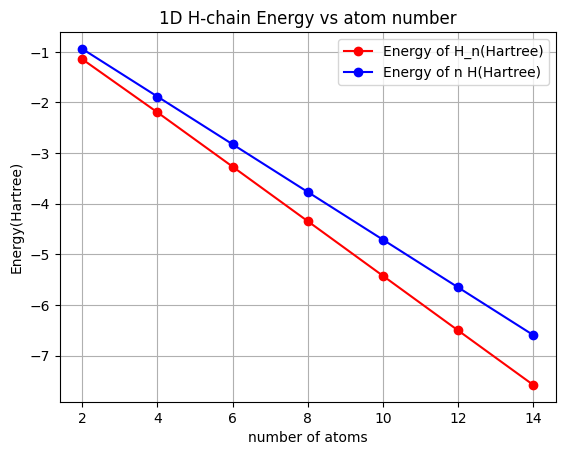

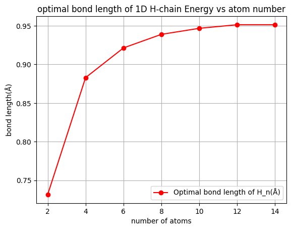

```python
import matplotlib.pyplot as plt
energy_H = compute_single_H_atom()
energy_Hn=[(r["energy"])for r in result]
energy_NH=[(r["n_atoms"]*energy_H)for r in result]
x = [(r["n_atoms"])for r in result]
plt.plot(x, energy_Hn, marker='o', linestyle='-', color='r', label='Energy of H_n(Hartree)')
plt.plot(x, energy_NH, marker='o', linestyle='-', color='b', label='Energy of n H(Hartree)')
plt.title('1D H-chain Energy vs atom number')
plt.xlabel('number of atoms')
plt.ylabel('Energy(Hartree)')
plt.legend()
plt.grid(True)
plt.show()
bond_length=[(r["optimal_bond_length"])for r in result]
plt.plot(x, bond_length, marker='o', linestyle='-', color='r', label='Optimal bond length of H_n(Å)')
plt.title("optimal bond length of 1D H-chain Energy vs atom number")
plt.xlabel('number of atoms')
plt.ylabel('bond length(Å)')
plt.legend()
plt.grid(True)
plt.show()
```

从以上图表可得，等间距的一维氢链在最优键长下基态能量低于等数量的独立氢原子，说明它在热力学上是稳定的。

但从最优键长随原子数增大而增大的趋势来看，这种结合的强度随着链的延长逐渐减弱，而且在n=2,n=4附近变化最为剧烈。

从这个角度来看，如果抛弃等间距的假设，将一维氢链分为若干小的单元，也许能够取得更低的基态能量。也就是说，等间距氢链可能其实是一种亚稳态。

##### 3.2.1 Peierls二聚化效应

考虑一个等间距的一维原子链，每个原子上有一个电子（半填充），能带结构是半满的。最低的一半能级被电子填满，费米能级恰好穿过能带的正中间。按照能带理论，体系有零能隙——这是金属。

但Peierls发现：如果把原子稍微推动一下，让它们两两靠近，形成"短键-长键"交替的结构。这时晶格周期从 $a$ 变成 $2a$，在费米波矢 $k_F = \pi/2a$ 处打开一个能隙。

二聚化是否发生，取决于两种能量的博弈：

|  | 对能量的影响 | 随二聚化位移 $\delta$ 的变化 |
| --- | --- | --- |
| **电子能** $E_{\text{电子}}$ | 能隙打开，占据态能量降低 | $\propto -\delta^2 \ln(1/\delta)$ |
| **弹性能** $E_{\text{弹性}}$ | 偏离平衡键长，晶格形变代价 | $\propto +\delta^2$ |

总能量变化： $$\Delta E(\delta) = \underbrace{A \delta^2}_{\text{弹性惩罚}} - \underbrace{B \delta^2 \ln\frac{1}{\delta}}_{\text{电子收益}}$$

当 $\delta$ 很小时，$\ln(1/\delta)$ 很大，电子收益**总是大于**弹性惩罚 → $\Delta E < 0$ → 故**任何一维半满金属在零温时必然二聚化**

通过我们的计算，如果最终发现$H_10$中二聚化确实发生，则说明一维氢链在热力学极限下是 Peierls 绝缘体，而非金属。

##### 3.2.2 构建二聚化坐标

在**二聚化结构**下原子按短键-长键交替排列

```
H₁ - H₂ —— H₃ - H₄ —— ...
```

对于偶数的 n，最后一对由短键连接。

依次给出原子坐标：

- `n_atoms` 原子个数
- `R_short` 短键长度
- `R_long` 长键长度

```python
def build_dimerized_coords(n_atoms, R_short, R_long):
    coords = []
    x = 0.0
    for i in range(n_atoms):
        coords.append(['H', (x, 0, 0)])
        if i % 2 == 0:
            x += R_short
        else:
            x += R_long
    return coords
```

##### 3.2.3 构建DMRG能量计算

- `basis='sto6g'` 此处基组选择STO-6G

```python
def compute_dimerized_energy(R_short, R_long, n_atoms=10, basis='sto6g',
                             bond_dims=None, verbose=0):

    coords = build_dimerized_coords(n_atoms, R_short, R_long)

    mol = gto.M(atom=coords, basis=basis, symmetry='c1', verbose=verbose)
    mf = scf.RHF(mol).run(conv_tol=1e-12)

    ret = itg.get_rhf_integrals(mf, ncore=0, ncas=None, g2e_symm=8)
    nso, nmo, ncore_out, ecore, h1e, g2e_compressed, orb_sym = ret

    from pyscf import ao2mo
    ncas = mf.mo_coeff.shape[1]
    g2e = ao2mo.restore(8, g2e_compressed, ncas)

    driver = DMRGDriver(scratch="./tmp_hchain", symm_type=SymmetryTypes.SU2,
                        n_threads=4)
    driver.initialize_system(n_sites=ncas, n_elec=n_atoms, spin=0, orb_sym=orb_sym)
    mpo = driver.get_qc_mpo(h1e=h1e, g2e=g2e, ecore=ecore, integral_cutoff=1e-12)

    if bond_dims is None:
        bond_dims = [50] * 4 + [100] * 4
    n_sweeps = len(bond_dims)
    noises = [1e-4] * 4 + [1e-5] * 4 + [0] * (n_sweeps - 8)
    if len(noises) < n_sweeps:
        noises += [0] * (n_sweeps - len(noises))
    thrds = [1e-8] * n_sweeps

    ket = driver.get_random_mps(tag="KET", bond_dim=bond_dims[0], nroots=1)
    energy = driver.dmrg(mpo, ket, n_sweeps=n_sweeps,
                         bond_dims=bond_dims, noises=noises, thrds=thrds, iprint=verbose)

    return energy, mf.e_tot
```

##### 3.2.4 二维粗扫描，寻找最优键长分配

截至目前，我们并不知道`R_short`和`R_long`应该是多少，我们需要通过计算机枚举，找到能得到最稳定的能量时的`R_short`和`R_long`。

```python
n_atoms = 10
R_short_range = np.arange(0.6, 1.3, 0.1)  # 短键：0.6 ~ 1.2 Å
R_long_range  = np.arange(0.8, 1.5, 0.1)  # 长键：0.8 ~ 1.4 Å
```

```python
results = []
for R_s in R_short_range:
    for R_l in R_long_range:
        if R_l <= R_s:
            continue  # 跳过无意义的组合（长键必须大于短键）
        try:
            energy, e_rhf = compute_dimerized_energy(
                R_s, R_l, n_atoms=10, basis='sto6g', verbose=0
            )
            results.append({
                'R_short': R_s, 'R_long': R_l,
                'E_DMRG': energy, 'E_RHF': e_rhf,
                'E_corr': energy - e_rhf
            })
            print(f"Rs={R_s:.1f} Å, Rl={R_l:.1f} Å → E_DMRG = {energy:.10f} Hartree")
        except Exception as e:
            print(f"Rs={R_s:.1f}, Rl={R_l:.1f} 计算出错: {e}")
```

[output not shown]

[output cut: 725 more lines]

```
 Site =     0 /    10 .. Mmpo =    13 DW = 0.00e+00 NNZ =       13 SPT = 0.0000 Tmvc = 0.001 T = 0.005
 Site =     1 /    10 .. Mmpo =    42 DW = 0.00e+00 NNZ =       89 SPT = 0.8370 Tmvc = 0.001 T = 0.008
 Site =     2 /    10 .. Mmpo =    64 DW = 0.00e+00 NNZ =      215 SPT = 0.9200 Tmvc = 0.001 T = 0.006
 Site =     3 /    10 .. Mmpo =    94 DW = 0.00e+00 NNZ =      333 SPT = 0.9446 Tmvc = 0.001 T = 0.009
 Site =     4 /    10 .. Mmpo =   132 DW = 0.00e+00 NNZ =      465 SPT = 0.9625 Tmvc = 0.001 T = 0.008
 Site =     5 /    10 .. Mmpo =    94 DW = 0.00e+00 NNZ =     1433 SPT = 0.8845 Tmvc = 0.001 T = 0.012
 Site =     6 /    10 .. Mmpo =    64 DW = 0.00e+00 NNZ =      335 SPT = 0.9443 Tmvc = 0.000 T = 0.004
 Site =     7 /    10 .. Mmpo =    42 DW = 0.00e+00 NNZ =      205 SPT = 0.9237 Tmvc = 0.000 T = 0.005
 Site =     8 /    10 .. Mmpo =    14 DW = 0.00e+00 NNZ =      101 SPT = 0.8282 Tmvc = 0.000 T = 0.011
 Site =     9 /    10 .. Mmpo =     1 DW = 0.00e+00 NNZ =       14 SPT = 0.0000 Tmvc = 0.000 T = 0.005
Ttotal =      0.074 Tmvc-total = 0.006 MPO bond dimension =   132 MaxDW = 0.00e+00
NNZ =         3203 SIZE =        43385 SPT = 0.9262

Rank =     0 Ttotal =      0.127 MPO method = FastBipartite bond dimension =     132 NNZ =         3203 SIZE =        43385 SPT = 0.9262
Rs=1.2 Å, Rl=1.4 Å → E_DMRG = -5.2926755468 Hartree
```

寻找最优的键长方案（对比result序列中能量最低的）

```python
if results:
    Rs = [r['R_short'] for r in results]
    Rl = [r['R_long'] for r in results]
    Es = [r['E_DMRG'] for r in results]
    R_avg = [(r['R_short'] + r['R_long']) / 2 for r in results]

    idx_min = np.argmin(Es)
    best = results[idx_min]

    print("H₁₀ Peierls 二聚化扫描结果 (粗精度)")
    print(f"最优短键长:   R_s* = {best['R_short']:.2f} Å")
    print(f"最优长键长:   R_l* = {best['R_long']:.2f} Å")
    print(f"平均键长:     R̄   = {(best['R_short'] + best['R_long'])/2:.2f} Å")
    print(f"最低能量:     E_dim = {best['E_DMRG']:.10f} Hartree")
    print(f"二聚化参数:   δ ≡ (R_l - R_s)/R̄ = {(best['R_long'] - best['R_short'])/((best['R_short'] + best['R_long'])/2):.3f}")
```

```
H₁₀ Peierls 二聚化扫描结果 (粗精度)
最优短键长:   R_s* = 0.70 Å
最优长键长:   R_l* = 1.40 Å
平均键长:     R̄   = 1.05 Å
最低能量:     E_dim = -5.6656960972 Hartree
二聚化参数:   δ ≡ (R_l - R_s)/R̄ = 0.667
```

把我们刚才扫描的各点的结果在同一幅图中呈现，结果如下：

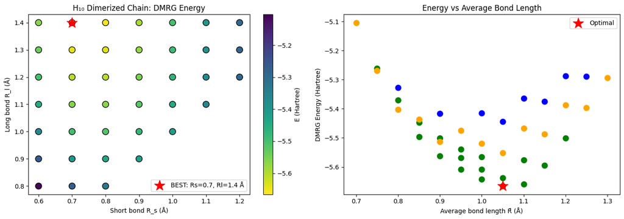

```python
import matplotlib.pyplot as plt

if results:
    Rs = [r['R_short'] for r in results]
    Rl = [r['R_long'] for r in results]
    Es = [r['E_DMRG'] for r in results]
    R_avg = [(r['R_short'] + r['R_long']) / 2 for r in results]

    fig, (ax1, ax2) = plt.subplots(1, 2, figsize=(14, 5))

    sc = ax1.scatter(Rs, Rl, c=Es, cmap='viridis_r', s=100, edgecolors='k')
    ax1.scatter(best['R_short'], best['R_long'], c='red', marker='*', s=300,
                label=f'BEST: Rs={best["R_short"]:.1f}, Rl={best["R_long"]:.1f} Å')
    ax1.set_xlabel('Short bond R_s (Å)')
    ax1.set_ylabel('Long bond R_l (Å)')
    ax1.set_title('H₁₀ Dimerized Chain: DMRG Energy')
    ax1.legend()
    plt.colorbar(sc, ax=ax1, label='E (Hartree)')

    for i, (rs, rl, e, ravg) in enumerate(zip(Rs, Rl, Es, R_avg)):
        delta = (rl - rs) / ravg
        if delta < 0.1:
            c = 'blue'
        elif delta < 0.3:
            c = 'orange'
        else:
            c = 'green'
        ax2.scatter(ravg, e, c=c, s=80)
    ax2.scatter((best['R_short']+best['R_long'])/2, best['E_DMRG'],
                c='red', marker='*', s=300, label='Optimal')
    ax2.set_xlabel('Average bond length R̄ (Å)')
    ax2.set_ylabel('DMRG Energy (Hartree)')
    ax2.set_title('Energy vs Average Bond Length')
    ax2.legend()

    plt.tight_layout()
    plt.show()
```

也可以看出我们找到的BEST确实是能量最低点，对应的键长约为0.7-1.4。此时的最低能量约为-5.67 Hartree，比10个H均匀分布的能量低。

其实观察上图就能发现，上图“对角线”位置（横纵坐标相等的位置），那些点的能量不是最低的，所以【平均分布不是能量最低的选择，这证明了peierls二聚化效应的存在。

##### 3.2.5 精细化扫描：确认最佳的键长

刚才的计算中我们选择的收敛性条件较为宽松，主要是为了在允许的计算条件下，得到$(R_s^*, R_l^*)$的大致位置。

接下来我们对粗扫到的 $(R_s^*, R_l^*)$ 附近区域，用更高的 bond_dim 和更严的收敛阈值重新计算，确认最优结构的正确性。

因为精细化扫描的耗时巨大，建议先完成粗扫描，确认粗扫描完成（如遇kernal连接中断等问题，请重新运行前面的代码）后，请**手动打开`DO_HIGH_PRECISION = True`**，否则默认状态下DO_HIGH_PRECISION = False（确保第一遍运行全部的时候不会卡死在这里~）

```python
DO_HIGH_PRECISION = False

if DO_HIGH_PRECISION and results:
    best = results[idx_min]

    Rs_fine = np.arange(best['R_short'] - 0.1, best['R_short'] + 0.15, 0.05)
    Rl_fine = np.arange(best['R_long'] - 0.1, best['R_long'] + 0.15, 0.05)

    bond_dims_high = [100] * 4 + [200] * 4 + [300] * 4
    n_sweeps = len(bond_dims_high)

    fine_results = []
    for R_s in Rs_fine:
        for R_l in Rl_fine:
            if R_l <= R_s:
                continue
            energy, e_rhf = compute_dimerized_energy(
                R_s, R_l, n_atoms=10, basis='sto6g',
                bond_dims=bond_dims_high, verbose=0
            )
            fine_results.append({
                'R_short': R_s, 'R_long': R_l,
                'E_DMRG': energy, 'E_RHF': e_rhf
            })
            print(f"[精细] Rs={R_s:.2f}, Rl={R_l:.2f} → E = {energy:.10f}")

    idx_fine = np.argmin([r['E_DMRG'] for r in fine_results])
    best_fine = fine_results[idx_fine]
    print(f"\n高精度最优: Rs*={best_fine['R_short']:.2f} Å, Rl*={best_fine['R_long']:.2f} Å")
    print(f"高精度能量: E = {best_fine['E_DMRG']:.12f} Hartree")
```

[output not shown]

[output cut: 448 more lines]

[output not shown]

计算结果：

```
高精度最优: Rs*=0.75 Å, Rl*=1.50 Å
高精度能量: E = -5.687967595571 Hartree
二聚化位移 δ = Rl* - Rs* = 0.75 Å
```

对比发现这组能量确实比0.7-1.4粗扫描的更低，也就是更趋于稳态。 因为真实的$H_{10}$结构应该形如：

```
O - O -- O - O -- O - O -- O - O -- O - O
```

##### 3.2.6 结果分析

有趣的是，我们惊喜计算得到的短键长度$0.75$与模块2.中通过查询化学实验中测得的$H_2$分子平均键长$0.74$非常接近，所以是否说明我们计算得到的$H_{10}$其实就是5个$H_2$独立存在呢？让我们验算

```python
E_H2 = energy_DMRG  # 前文STO-3G计算值

E_H10_dimer = best_fine['E_DMRG']
E_H10_5xH2 = 5 * E_H2

print("="*60)
print("H₁₀ 二聚化结构 vs 5个独立H₂分子")
print("="*60)
print(f"5 × E_H2          = {E_H10_5xH2:.10f} Hartree")
print(f"E_H10 (二聚化最优) = {E_H10_dimer:.10f} Hartree")
print(f"差值              = {E_H10_dimer - E_H10_5xH2:.10f} Hartree")
print(f"                  = {(E_H10_dimer - E_H10_5xH2) * 27.2114:.4f} eV")
print(f"相对误差           = {abs(E_H10_dimer - E_H10_5xH2) / abs(E_H10_5xH2) * 100:.4f}%")
print("="*60)
print("结论: H₁₀二聚化的短键单元 ≈ 几乎独立的H₂分子")
```

```
============================================================
H₁₀ 二聚化结构 vs 5个独立H₂分子
============================================================
5 × E_H2          = -5.6864191724 Hartree
E_H10 (二聚化最优) = -5.6879675956 Hartree
差值              = -0.0015484231 Hartree
                  = -0.0421 eV
相对误差           = 0.0272%
============================================================
结论: H₁₀二聚化的短键单元 ≈ 几乎独立的H₂分子
```

好吧，看来所谓的$H_{10}$就是5个氢气分子 >_<

说明长氢链几乎无法稳定存在，二聚化效应会使得它们直接“抱团”两两形成小分子，这严格符合量子计算下能量最低的分布。

完结撒花！！！